# Midpoint Deliverable

### Introduction to our project

We are business, economics, and computational finance majors, and we felt that the field of housing markets intersected all of our major-related interests, so we chose to focus on it for our project. The data sets we decided to use come from Zillow. Zillow regularly gathers information about all of the homes listed for sale on their website and makes it publicly available, and we decided to make use of several pieces of it. The first lists the median housing prices across the nation according to different regional categories. It can be used to answer questions about how house prices vary by geographic region, as well as how they’ve changed over the past ten years. The second lists the average number of days a listing stays on Zillow by region. This can be used to examine changes in the speed with which houses sell in different areas. The pricing data was downloaded [here](https://data.world/zillow-data/median-list-price/) and the listing data was downloaded [here](https://data.world/zillow-data/days-on-zillow).

### Summary Code

Looking at the dataset, which displays US city median house prices, we can note a few pieces of interesting information. According to the data, the city with the highest median house price in 2017 was Golden Beach, while the city with the lowest median house price was Johnstown. The average median US city house price was 299766.575361708 in 2017. These values demonstrate that house price varies significantly depending on the city. The median 2017 house price in New York, which is the largest city in the dataset, was 728000. The median 2017 house price in Winterset, which is tied for the smallest city listed in the data, was 255000. This data suggests that the size of city might be correlated with the price.

### Aggregate Table

The table created displays the highest 15 listing prices for the data sets. The grouping calculation was done with “RegionName” because that column is what identifies the location type of the data set (City). The “RegionName” column is present in every data set so that is why it is used. By using city to group, we can tell which cities have the highest prices.

### **Top 15 Cities by Median Price**

| City | Median Price ($) |
| --- | --- |
| Golden Beach | 5930850 |
| Hidden Hills | 5052000 |
| Montecito | 4376727 |
| Fisher Island | 4255238 |
| Water Mill | 3732078 |
| Malibu | 3350362 |
| Bridgehampton | 3277467 |
| Del Mar | 3211853 |
| Newport Coast | 3039645 |
| Amagansett | 2947628 |
| Rancho Santa Fe | 2825776 |
| San Marino | 2686564 |
| Upper Brookville | 2667183 |
| Quogue | 2659083 |
| Sag Harbor | 2655533 |

One key insight from this table is that most of these listed cities are not big, well-known cities. Another trend noticed is words like “island”, “harbor”, and “beach” appearing in some of these city names, implying that a lot of the most expensive cities are near bodies of water.

### Chart Number 1: Map

This map attempts to display the geographic spread of the data by placing a marker at each city mentioned in the data set. The size of the marker is scaled linearly on the median house price in September 2017

[interactive chart not shown]

### Chart Number 2: Bar Graph

This bar plot takes the average of the given median house prices at the beginning of each year to illustrate annual changes in house price

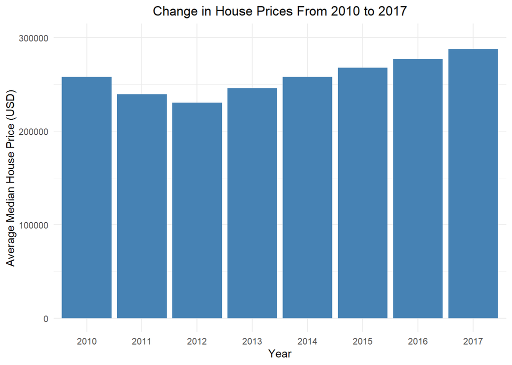

This bar graph shows how prices have dropped from 2010 to 2012. And prices have risen from 2012 to 2017. Prices were slightly higher in 2017 than in 2010, indicating a general trend that house prices increase.

### Chart Number 3: Line Graph

This line graph looks at the average number of days a house remains listed on Zillow by time, and it breaks the data down by region. It answers questions such as “When did houses take the longest time to sell?”, and it will takes user input to decide which region to show. Below is an example of King County, and Washington as a whole.

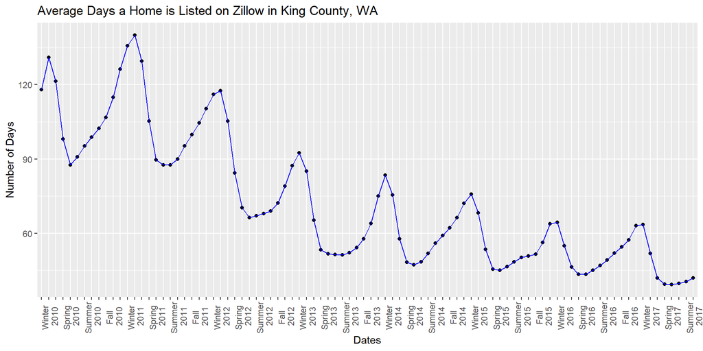

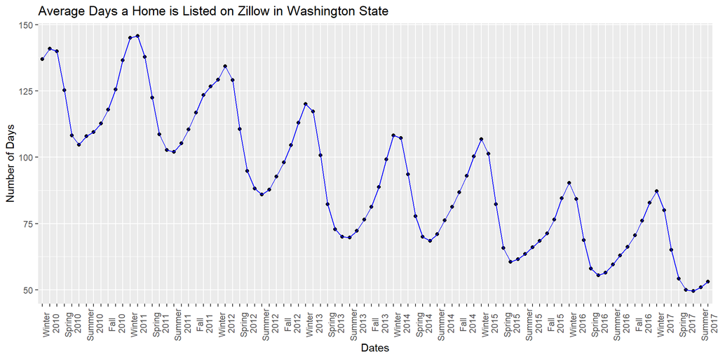